# Lecture 3 – Linear Regression and Extensions

2016-04-26

## Extensions

- Polynomial Regression
- Step Functions
- Basis Functions
- Regression Splines
- Smoothing Splines

## Regression Splines

- Polynomial regressions often leads to rough and instable estimates.
- Solution: Fitting separate low-degree polynomials over different regions (and make them smooth)
- Construction of splines:
- Partition x-axis into different smaller sub-intervals and estimate a separate polynomial for each interval.
- Additionally, it is required that the combined function is smooth (e.g. continuously differentiable) at the boundary points (knots).

## Regression Splines

### Defintion

Let \(a=c_1 < c_2 < \ldots < c_K=b\) be a partition of the interval \([a,b]\). A function \(s: [a,b] \rightarrow \mathbb{R}\) is called a polynomial spline of degree \(l\) if

1. \(s(z)\) is a polynomial of degree \(l\) for \(z \in [c_j, c_{j+1}), 1 \leq j < m.\)
2. \(s(z)\) is \((l-1)\)-times continuously differentiable.

\(c_1, \ldots, c_K\) are called knotes of the splines and \(\Omega=\{ c_1,\ldots, c_k\}\) knot set.

## Regression Splines

It can be shown that regression splines form a vector space of dimension of dimension \(K+l-1\).

Hence every regression spline can be represented as the sum of \(K+l-1\) basis functions:

\[ s(z) = \beta_0 B_0(z) + \ldots + \beta_{k+l-2} B_{K+l-2}(z).\]

Basis functions: truncated power series basis, B-spline basis (numerical more stable)  
Truncated power series:  
\[s(z) = \sum_{j=0}^l \beta_j z^j + \sum_{j=2}^{K-1} \beta_{l+j-1} (z-c_j)^l_+\]with \((z-c_j)^l_+ = \max(0, (z-c_j))^l\).

## Regression Splines

### Example Basis Functions

We consider the interval \([0,1]\) and knots \(0<0.25<0.5<0.75<1\).

For a quadratic spline and 5 knots, the number of basis functions is given by \(2+5-1=6\).

## Regression Splines

### Example Basis Functions

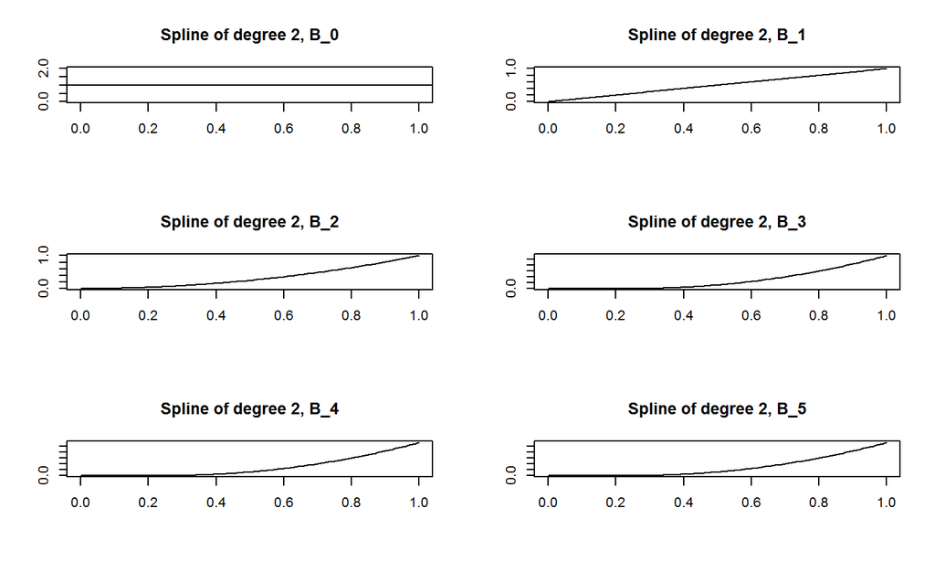

## Regression Splines

How to choose the number and location of knots?

- Equi-distant knots
- Choice according to quantiles of the x-variable

## Regression Splines

### Example

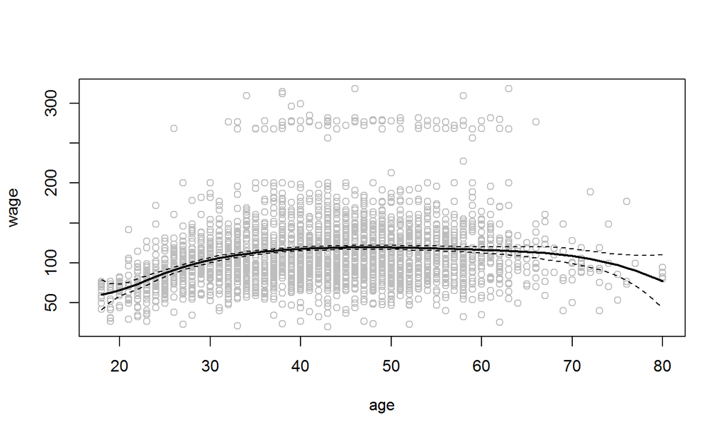

## Natural Splines

- Problem: Regression splines tend to display erratic behavior at the boundaries of the domain leading to high variance.
- Solution: additional constraints at the boundary (left of the leftmost knot and right of the most rightmost knot)
- Definition **Natural Spline**  
  A natural spline of degree \(l\) is a regression spline of degree \(l\) with the additional constraint that  
  it is a polynomial of degree \((k-1)/2\) on \((-\infty, c_0]\) and \([c_K, + \infty)\).
- Most popular natural splines are cubic which are linear beyond the boundaries.
- Modifications of the truncated power basis and B-spline basis for natural splines (here dimension \(K\)!)

## Smoothing Splines

- Optimization problem: Among all functions \(f(x)\) with two continuous derivatives, minimize:\[ RSS(f, \lambda) = \sum_{i=1}^n (y_i -f(x_i))^2 + \lambda \int (f''(t))^2dt \]
- \(\lambda\) is called *smoothing parameter* (interpretation?)
- It can be shown that the solution of the optimization problem is unique and a natural cubic spline with knots at the unique values of the \(x_i, i=1,\ldots,n\).
- Here: no problem how to choose the knots (as in the regression spline case)
- Intuition: Overparametrization (because of \(n\) knots), but penalization

## Snoothing Splines

Since the solution is a natural spline, we can write it as

\[ f(x) = \sum_{j=1}^n b_j(x) \beta_j \]

with \(b_1(\cdot), \ldots, b_n(\cdot)\) an \(n\) dimensional set of basis functions for representing the family of natural splines.

## Snoothing Splines

Then the criterion reduces to

\[ RSS(\beta, \lambda) = (y-B \beta)^T (y-B \beta) + \lambda \beta^T \Omega_n \beta \]

where \(B_{ij}=b_j(x_i)\) and \((\Omega_n)_{jk}=\int b_j''(d) b_k''(t)dt.\)

The solution is given by

\[ \hat{\beta}=(B^TB + \lambda \Omega_n)^{-1}B^T y.\](generalized Ridge regression).

## Snoothing Splines

The fitted smoothing spline is given by

\[\hat{f}(x) = \sum_{j=1}^n b_j(x) \hat{\beta_j}\]